# Practical Machine Learning Project

## Synopsis

In this project, we aim to predict how good people practice sport given data collected from various devices. A training data file is provided to be used for training and selecting a model for predicting results from the testing data.

As we have to test and compare different models, we choose the k-folds cross validation method. We train and test our models on data defined in the original training data.

From results, the Random Forest model is the best for this example. The accurancy of the model is about 99%. We give results on the testing data at the end of this report.

## Load and preprocess Data

We load the necessary packages.

```r
library(caret)
library(rpart)
library(randomForest)
```

We download both training and testing data from the given addresses, then load them.

```r
trainingData <- read.csv("pml-training.csv", na.strings = c("", "NA", "#DIV/0!"))
testingData <- read.csv("pml-testing.csv", na.strings = c("", "NA", "#DIV/0!"))
```

Data need to be cleaned from columns containing mostly NA values.

```r
noNAColumns <- colSums(is.na(trainingData)) < nrow(trainingData) * 0.9
training <- trainingData[,noNAColumns]
testing <- testingData[,noNAColumns]
```

We Remove also the first column “X”, as it’s only the row number.

```r
training <- training[,-1]
testing <- testing[,-1]
```

## Cross validation

As we need to test different models, we need to do a cross validation. We choose to apply the k-folds method. The training data is splitted into k (in our case k=5) training and testing data.

```r
set.seed(200)
nFolds <- 5
folds <- createFolds(y=training$classe, k=nFolds, list = TRUE, returnTrain = FALSE)

testData <- list()
trainData <- list()

for(i in 1:nFolds){
    testIndexes <- folds[[i]]
    testData[[i]] <- training[testIndexes,]
    trainData[[i]] <- training[-testIndexes,]
}
```

## Build the model

We will try two models for prediction and compare the obtained results. The two models are decision trees and random forests.

### Decision Trees

First, we try the Decision Trees model. We apply the “rpart” command to the training data set and predict with the testing data set. We save the accurancy each time.

```r
rpartAcc <- numeric(nFolds)

for(i in 1:nFolds){
    rPartMod <- rpart(classe ~ ., data=trainData[[i]], method="class")
    pred <- predict(rPartMod, testData[[i]], type="class")
    res <- confusionMatrix(pred, testData[[i]]$classe)
    rpartAcc[i] <- res$overall[1]
}
```

The accurancy mean for this model is

```r
mean(rpartAcc)
```

```
## [1] 0.8704503
```

### Random forests

Now we try the Random Forest model with the randomForest method.

```r
rfAcc <- numeric(nFolds)

for(i in 1:nFolds){
    rfMod <- randomForest(classe ~ ., data=trainData[[i]])
    pred <- predict(rfMod, testData[[i]], type="class")
    res <- confusionMatrix(pred, testData[[i]]$classe)
    rfAcc[i] <- res$overall[1]
}
```

The accurancy mean for the random forest model is

```r
mean(rfAcc)
```

```
## [1] 0.9990825
```

### Comparing models

We plot the accurancies of both decision trees and random forest models. We can see that the random forest model accurancy is clearly better that the decision tree one.

So, we’ll use the random forest model for predicting the testing data.

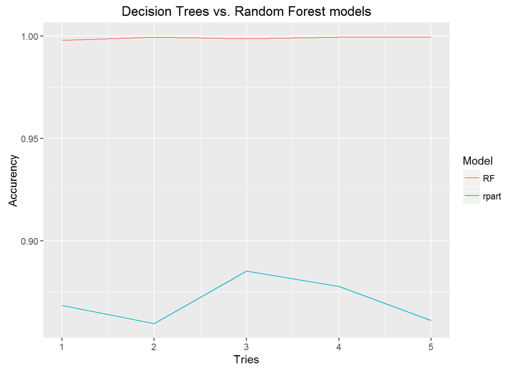

```r
dat <- data.frame(Tries = c(1:nFolds, 1:nFolds), Accurency = c(rpartAcc, rfAcc), Model = c(rep("rpart",nFolds),rep("RF",nFolds)))

g <- ggplot(dat, aes(x=Tries,y=Accurency, col=Model))
g <- g + geom_line()
g <- g + ggtitle("Decision Trees vs. Random Forest models")
g
```

## Predicting on test data

After slight changes on the testing data, we apply the random forest model and display the results.

```r
levels(testing$new_window) <- levels(training$new_window)
levels(testing$cvtd_timestamp) <- levels(training$cvtd_timestamp)

predTestRF <- predict(rfMod, newdata=testing)
predTestRF
```

```
##  1  2  3  4  5  6  7  8  9 10 11 12 13 14 15 16 17 18 19 20
##  B  A  B  A  A  E  D  B  A  A  B  C  B  A  E  E  A  B  B  B
## Levels: A B C D E
```